# numpy get started

```python
import numpy as np
```

导入numpy库，并查看numpy版本

```python
np.__version__
```

```
'1.17.0'
```

```python
l = [[1,2,3,4], [3,4,5,6]]
l[0][1]
```

```
2
```

```python
numpy ndarray n dimension array
```

```python
ndarray不是真正的矩阵
```

```python
一切皆矩阵
```

```python
import matplotlib.pyplot as plt
%matplotlib inline
```

```python
cat = plt.imread('./cat.jpg')
cat
```

```
array([[[231, 186, 131],
        [232, 187, 132],
        [233, 188, 133],
        ...,
        [100,  55,  52],
        [ 92,  48,  49],
        [ 85,  43,  44]],

       [[232, 187, 132],
        [232, 187, 132],
        [233, 188, 133],
        ...,
        [100,  55,  52],
        [ 92,  48,  49],
        [ 84,  42,  43]],

       [[232, 187, 132],
        [233, 188, 133],
        [233, 188, 133],
        ...,
        [ 99,  54,  51],
        [ 91,  47,  48],
        [ 83,  41,  42]],

       ...,

       [[199, 119,  82],
        [199, 119,  82],
        [200, 120,  83],
        ...,
        [189,  99,  64],
        [187,  97,  62],
        [187,  97,  62]],

       [[199, 119,  82],
        [199, 119,  82],
        [199, 119,  82],
        ...,
        [188,  98,  64],
        [188,  95,  62],
        [188,  95,  62]],

       [[199, 119,  82],
        [199, 119,  82],
        [199, 119,  82],
        ...,
        [188,  98,  64],
        [188,  95,  62],
        [188,  95,  62]]], dtype=uint8)
```

```python
jpg结尾的图片是颜色从0到255的整数
png结尾的图片是颜色从0到1的小数
```

```python
!pip install pillow
```

## 一、创建ndarray

### 1. 使用np.array()由python list创建

参数为列表： [1, 4, 2, 5, 3]

```python
l
```

```
[[1, 2, 3, 4], [3, 4, 5, 6]]
```

```python
n = np.array(l)
n
```

```
array([[1, 2, 3, 4],
       [3, 4, 5, 6]])
```

```python
n[0,0] = 8
```

```python
n
```

```
array([[8, 2, 3, 4],
       [3, 4, 5, 6]])
```

```python
l
```

```
[[1, 2, 3, 4], [3, 4, 5, 6]]
```

注意：

- numpy默认ndarray的所有元素的类型是相同的
- 如果传进来的列表中包含不同的类型，则统一为同一类型，优先级：str>float>int

```python
np.array([1,2,3.9,  '4.5']) # str > float > int
```

```
array(['1', '2', '3.9', '4.5'], dtype='<U32')
```

### 2. 使用np的routines函数创建

包含以下常见创建方法：

1) np.ones(shape, dtype=None, order='C')

```python
# 创建全是1的ndarray, 默认是float64类型
np.ones(shape=(4,5))
```

```
array([[1., 1., 1., 1., 1.],
       [1., 1., 1., 1., 1.],
       [1., 1., 1., 1., 1.],
       [1., 1., 1., 1., 1.]])
```

2) np.zeros(shape, dtype=float, order='C')

```python
# 全是0的ndarray
np.zeros(shape=(8,8))
```

```
array([[0., 0., 0., 0., 0., 0., 0., 0.],
       [0., 0., 0., 0., 0., 0., 0., 0.],
       [0., 0., 0., 0., 0., 0., 0., 0.],
       [0., 0., 0., 0., 0., 0., 0., 0.],
       [0., 0., 0., 0., 0., 0., 0., 0.],
       [0., 0., 0., 0., 0., 0., 0., 0.],
       [0., 0., 0., 0., 0., 0., 0., 0.],
       [0., 0., 0., 0., 0., 0., 0., 0.]])
```

3) np.full(shape, fill_value, dtype=None, order='C')

```python
# 使用指定的元素来填充,
np.full(shape=(8,8), fill_value=8, dtype=np.float64)
```

```
array([[8., 8., 8., 8., 8., 8., 8., 8.],
       [8., 8., 8., 8., 8., 8., 8., 8.],
       [8., 8., 8., 8., 8., 8., 8., 8.],
       [8., 8., 8., 8., 8., 8., 8., 8.],
       [8., 8., 8., 8., 8., 8., 8., 8.],
       [8., 8., 8., 8., 8., 8., 8., 8.],
       [8., 8., 8., 8., 8., 8., 8., 8.],
       [8., 8., 8., 8., 8., 8., 8., 8.]])
```

4) np.eye(N, M=None, k=0, dtype=float)  
对角线为1其他的位置为0

```python
# 生成对角线上全是1, 其他位置全是0 的二维ndarray
np.eye(8,  k=-1)
```

```
array([[0., 0., 0., 0., 0., 0., 0., 0.],
       [1., 0., 0., 0., 0., 0., 0., 0.],
       [0., 1., 0., 0., 0., 0., 0., 0.],
       [0., 0., 1., 0., 0., 0., 0., 0.],
       [0., 0., 0., 1., 0., 0., 0., 0.],
       [0., 0., 0., 0., 1., 0., 0., 0.],
       [0., 0., 0., 0., 0., 1., 0., 0.],
       [0., 0., 0., 0., 0., 0., 1., 0.]])
```

```python
行列数相同的矩阵叫做方阵, 主对角线全是1, 其他位置全是0的方阵叫做单位矩阵.单位矩阵相当于实数里的1, 乘于任何矩阵,等于矩阵本身.
```

5) np.linspace(start, stop, num=50, endpoint=True, retstep=False, dtype=None)

```python
# 等分一个范围
np.linspace(0, 100, num=50, endpoint=False, retstep=True)
```

```
(array([ 0.,  2.,  4.,  6.,  8., 10., 12., 14., 16., 18., 20., 22., 24.,
        26., 28., 30., 32., 34., 36., 38., 40., 42., 44., 46., 48., 50.,
        52., 54., 56., 58., 60., 62., 64., 66., 68., 70., 72., 74., 76.,
        78., 80., 82., 84., 86., 88., 90., 92., 94., 96., 98.]), 2.0)
```

6) np.arange([start, ]stop, [step, ]dtype=None)

```python
# 和python的 range一样
# 当step是非整数的时候,尽量使用np.linspace
np.arange(0, 100)
```

```
array([ 0,  1,  2,  3,  4,  5,  6,  7,  8,  9, 10, 11, 12, 13, 14, 15, 16,
       17, 18, 19, 20, 21, 22, 23, 24, 25, 26, 27, 28, 29, 30, 31, 32, 33,
       34, 35, 36, 37, 38, 39, 40, 41, 42, 43, 44, 45, 46, 47, 48, 49, 50,
       51, 52, 53, 54, 55, 56, 57, 58, 59, 60, 61, 62, 63, 64, 65, 66, 67,
       68, 69, 70, 71, 72, 73, 74, 75, 76, 77, 78, 79, 80, 81, 82, 83, 84,
       85, 86, 87, 88, 89, 90, 91, 92, 93, 94, 95, 96, 97, 98, 99])
```

7) np.random.randint(low, high=None, size=None, dtype='l')

```python
# 全是整数的ndarray 左闭右开区间.
np.random.randint(0,  150, size=(4,6,3), )
```

```
array([[[138, 118,   1],
        [ 85, 128,  29],
        [ 99,  93,  65],
        [ 61, 107,  57],
        [ 63,  27,   3],
        [ 82, 130,  54]],

       [[102,   2,  17],
        [ 79,  45,  11],
        [  1, 116,  73],
        [ 21, 134,   4],
        [ 28,  62,  83],
        [142,  14,  81]],

       [[102,  25,  83],
        [ 82,  57, 101],
        [ 39,   3,  34],
        [110,  98, 113],
        [118, 145,  44],
        [ 93, 133,   2]],

       [[ 55,  80,   6],
        [ 47, 138,   3],
        [ 81,  19,  60],
        [ 68,  80, 129],
        [ 97,  49, 129],
        [ 62,  81,  85]]])
```

```python
import random
```

```python
# 全闭区间
random.randint()
```

8) np.random.randn(d0, d1, ..., dn)

标准正太分布

```python
# 平均值为0, 方差 为1 的正态分布叫做标准正态分布
np.random.randn(4, 5, 3,6)
```

```
array([[[[ 1.82236803e+00, -7.29617302e-01,  6.59690415e-01,
          -1.26593618e+00, -4.04539537e-01, -2.07273845e-01],
         [-1.23564830e+00,  1.15462750e-01, -7.78660362e-01,
          -6.49588606e-01,  2.12659634e+00, -8.85355904e-01],
         [-1.36549479e-01, -7.27614925e-01, -2.19178211e+00,
           1.56938894e+00,  3.90561520e-01, -1.32797485e+00]],

        [[-8.03622097e-01, -2.69080739e-01,  4.20487235e-01,
           1.00967248e+00,  1.74215140e+00,  1.57981234e+00],
         [ 1.25780320e+00,  8.18451476e-01, -1.86332826e-02,
          -6.70753486e-01,  6.02509819e-01, -6.66254459e-01],
         [-1.54404136e+00,  1.23820449e+00,  1.00206713e-01,
          -6.51488658e-01, -1.19375075e+00,  5.58960126e-01]],

        [[-8.92846446e-03,  2.71315498e+00,  4.31587580e-01,
           1.90556356e+00,  1.99898845e+00, -4.38912172e-01],
         [-5.68639604e-01, -1.62415610e+00,  1.40455332e+00,
           1.82841490e+00, -5.93912037e-01,  1.06140999e+00],
         [-9.39655420e-01, -2.19630439e-01,  3.17259628e-01,
           7.59513745e-01, -3.41242907e-01, -3.22101639e-01]],

        [[ 8.01254592e-01, -1.78391544e+00,  7.36072981e-02,
          -1.34019781e+00,  1.72541044e+00,  7.15193879e-01],
         [-4.32560917e-01, -4.07839595e-01, -8.79445193e-01,
           1.98319045e+00, -5.98511708e-01,  4.92547912e-01],
         [ 1.49440671e+00, -7.42743073e-01,  5.34807029e-01,
          -5.63453897e-01,  1.05105858e+00, -1.29259324e-01]],

        [[ 4.33205403e-01,  7.07119217e-01, -1.24890303e+00,
           1.21190812e+00, -3.01269223e-01, -1.34524496e+00],
         [-8.03556582e-01,  1.20200184e-01, -3.06482497e-02,
           9.85232142e-01,  6.22251368e-01,  1.89368166e+00],
         [-8.52202393e-01,  2.50015300e+00,  1.18634637e+00,
           7.42937730e-01, -2.61246964e-01, -3.83049766e-01]]],


       [[[ 3.52068214e-02,  1.64618609e+00,  2.46597832e-01,
           4.48160319e-02, -3.73212028e-01, -5.33339792e-01],
         [ 2.94779738e-01,  1.21759448e+00,  1.01864365e+00,
           7.88764683e-01, -4.69297873e-01, -7.54373971e-01],
```

[output cut: 87 more lines]

```
           1.00713992e+00, -1.26793903e-01, -3.91972732e-01]],

        [[ 5.38579087e-01, -1.52949121e+00,  4.89492930e-02,
          -1.01636125e+00,  8.33841355e-02, -1.52882641e+00],
         [-3.06054926e-01, -4.72420488e-01, -9.89285159e-01,
          -9.31534455e-01, -5.07338101e-01, -3.81165239e-01],
         [-8.29928983e-02,  5.15888657e-01, -5.14258888e-01,
          -6.96352676e-01,  6.01603997e-02, -5.28166746e-01]],

        [[-2.77152500e+00,  1.66717736e+00, -5.11563808e-01,
          -3.17237715e-01, -1.21854795e+00,  2.52321350e-01],
         [-1.15485879e+00,  7.74328722e-01,  5.14075576e-01,
          -3.08386513e-01,  1.63796707e+00, -8.21515669e-02],
         [-2.21626653e-01, -1.39986944e+00, -4.03947613e-02,
           6.42542914e-01, -2.21143246e+00, -1.78809305e-01]]]])
```

9)np.random.normal(loc=0.0, scale=1.0, size=None)

```python
# 正态分布
np.random.normal(loc=10, scale=3,  size=(10,10))
```

```
array([[16.31584686,  7.17692638,  6.04556215,  6.39617985, 15.67661444,
        10.61685845,  8.67515293, 11.38196698,  8.42000065,  4.4850963 ],
       [ 3.8404623 , 13.90254197, 11.39298938, 10.66412711, 10.71880537,
        11.27059654,  8.06575364, 14.58926408, 12.72547701, 12.17345346],
       [12.91966306,  8.99564262, 11.600821  ,  8.75425456, 11.47986971,
        16.02285892, 14.12123596, 12.28549064,  8.87430389, 12.78593865],
       [13.81745361, 10.41487822, 14.32572415, 10.59422252,  8.6136368 ,
         8.76289092, 12.74685966, 10.75204813,  6.82587487,  7.00016929],
       [ 5.24895916,  9.71893446,  6.60833938, 13.00947007, 14.09106653,
        12.66099367,  7.72049732, 14.13767616,  8.34482224, 12.00627442],
       [15.61258147,  7.58948559, 13.78933605,  5.37139276, 11.77677271,
        14.24028046, 11.13374745, 14.77759819,  9.25022978,  8.89316251],
       [ 4.56751562,  9.739684  ,  9.84442085,  6.78508694, 13.78291913,
        14.47990616,  8.10093652, 13.54042019,  8.87245247,  9.56803193],
       [ 9.395695  , 11.74029701,  4.86318586,  5.77361606,  9.55269003,
         6.60323204, 10.29224487,  9.16723161, 11.30057422, 11.31569913],
       [10.80005832,  5.08697206, 10.8790688 , 12.89230448, 12.6105899 ,
         4.83561244, 10.61628965, 10.15518887,  9.11899709,  5.23803308],
       [10.55832686, 11.84059923, 11.44858283, 12.8216855 , 12.67019686,
        10.37184972,  7.19762662, 11.22911998,  9.49082684,  8.68004938]])
```

10) np.random.random(size=None)

生成0到1的随机数，左闭右开

```python
np.random.random(size=(4,5,6))
```

```
array([[[0.41056458, 0.28485968, 0.42495929, 0.5056295 , 0.34541796,
         0.40681562],
        [0.07643229, 0.39898439, 0.87241508, 0.02071669, 0.96650027,
         0.42784584],
        [0.51707471, 0.67970599, 0.34986409, 0.11863721, 0.53447635,
         0.37762957],
        [0.41501785, 0.2257569 , 0.69345885, 0.37606333, 0.2876514 ,
         0.72617843],
        [0.88752894, 0.62925951, 0.20825071, 0.2354294 , 0.8501692 ,
         0.21447085]],

       [[0.67329005, 0.07358668, 0.08331723, 0.1195677 , 0.4340253 ,
         0.40626631],
        [0.45523716, 0.93873912, 0.6797238 , 0.11191947, 0.32668495,
         0.68006259],
        [0.91068643, 0.66432765, 0.84740787, 0.7223536 , 0.80694573,
         0.07264082],
        [0.41075309, 0.90154862, 0.34549977, 0.77695087, 0.13064724,
         0.72074661],
        [0.76762757, 0.61045187, 0.41127966, 0.01288982, 0.63283578,
         0.32106198]],

       [[0.07235036, 0.15295457, 0.35670191, 0.3826919 , 0.16485406,
         0.81934564],
        [0.41271016, 0.90652241, 0.43953267, 0.18384573, 0.80229586,
         0.32360069],
        [0.31215358, 0.90542585, 0.0489333 , 0.4819161 , 0.08083296,
         0.15539332],
        [0.47666805, 0.69052714, 0.18384834, 0.48860877, 0.08904913,
         0.42682927],
        [0.42337744, 0.03678738, 0.16077953, 0.76773947, 0.08914534,
         0.12734038]],

       [[0.7547738 , 0.4153287 , 0.59000252, 0.67175392, 0.49858525,
         0.15811732],
        [0.58800442, 0.11918735, 0.02469043, 0.1232169 , 0.46044534,
         0.78525041],
        [0.30195454, 0.45858692, 0.33264132, 0.16275501, 0.83918399,
         0.07131157],
        [0.17510794, 0.81852551, 0.36197747, 0.16274869, 0.62171884,
         0.66388601],
        [0.53807344, 0.43572056, 0.63218357, 0.19061914, 0.55153725,
         0.72531121]]])
```

```python
# 和np.random.random一样
np.random.rand(4,5,6)
```

```
array([[[0.68973888, 0.10072742, 0.83366428, 0.56437841, 0.06198735,
         0.70650265],
        [0.25105733, 0.20180056, 0.17131604, 0.79020262, 0.03332404,
         0.166792  ],
        [0.1926571 , 0.52164632, 0.6581185 , 0.57725744, 0.94828229,
         0.68790996],
        [0.86326205, 0.49759305, 0.25118012, 0.85122611, 0.33528223,
         0.34284636],
        [0.11073423, 0.8231773 , 0.28078196, 0.47301091, 0.75014866,
         0.52140067]],

       [[0.21401898, 0.78073236, 0.35731152, 0.28571548, 0.76979951,
         0.89148798],
        [0.71766898, 0.31719556, 0.75819455, 0.64670927, 0.61129524,
         0.77902943],
        [0.17867826, 0.57770045, 0.32539753, 0.25369393, 0.5263867 ,
         0.5220019 ],
        [0.61435625, 0.67013936, 0.4840525 , 0.49926269, 0.33517794,
         0.76859471],
        [0.72157626, 0.8056766 , 0.38446784, 0.28768618, 0.28972332,
         0.38369389]],

       [[0.51987304, 0.65424102, 0.36307275, 0.34806826, 0.87827803,
         0.22234622],
        [0.13273201, 0.17129019, 0.73762626, 0.45282127, 0.75194743,
         0.08824132],
        [0.71480334, 0.62750066, 0.89762021, 0.86589893, 0.63711456,
         0.98544125],
        [0.17754347, 0.35003405, 0.06866705, 0.36395498, 0.53358599,
         0.80491728],
        [0.7168657 , 0.76508564, 0.76683125, 0.66511502, 0.48867865,
         0.98063728]],

       [[0.6296038 , 0.46908196, 0.5235053 , 0.46767733, 0.45367426,
         0.99191901],
        [0.62149261, 0.72358639, 0.23638867, 0.54334487, 0.61322429,
         0.99715943],
        [0.83432701, 0.73848151, 0.18890094, 0.57549454, 0.03115784,
         0.76856343],
        [0.42041441, 0.38506018, 0.22209195, 0.05312593, 0.2989828 ,
         0.45011793],
        [0.28992335, 0.48166372, 0.21327063, 0.08372843, 0.59573821,
         0.65797149]]])
```

## 二、ndarray的属性

4个必记参数： ndim：维度 shape：形状（各维度的长度） size：总长度

dtype：元素类型

```python
n = np.random.randint(0,150,size=(4,6))
n
```

```
array([[122,  80, 147, 113,  66, 144],
       [109, 135,  28,  20, 139,  46],
       [ 91,  30,  57, 100,  44,  44],
       [143,  32,  50,  75,  61,  81]])
```

```python
n.ndim
```

```
2
```

```python
n.shape
```

```
(4, 6)
```

```python
n.size # 元素的个数
```

```
24
```

```python
n.dtype
```

```
dtype('int32')
```

## 三、ndarray的基本操作

### 1. 索引

一维与列表完全一致 多维时同理

```python
l = [1,2,3,4,5]
n = np.array(l)
n
```

```
array([1, 2, 3, 4, 5])
```

```python
l[0]
```

```
1
```

```python
n[0]
```

```
1
```

```python
n = np.random.randint(0,150, size=(4,5))
n
```

```
array([[ 81,  47,  74,  90,  35],
       [ 25,  45,  62,  89, 104],
       [  6,  66, 126,  74, 124],
       [  2,  81, 104,  19,  50]])
```

```python
n[0][0]
```

```
81
```

```python
n[0][0]
```

```
81
```

```python
# 推荐写法
n[0, 0]
```

```
81
```

```python
n = np.random.randint(0,100, size=(4,5,3))
```

```python
n
```

```
array([[[69, 59, 34],
        [72, 41, 59],
        [62,  8, 72],
        [92,  7, 87],
        [25, 80, 43]],

       [[57, 31, 97],
        [34, 85, 84],
        [47, 23, 21],
        [ 1, 78, 65],
        [73, 36, 98]],

       [[10, 12, 57],
        [76, 29,  6],
        [78,  7, 95],
        [54, 42, 18],
        [40, 42, 32]],

       [[25, 70,  3],
        [75, 57, 72],
        [15,  4, 65],
        [22, 19, 72],
        [21, 38, 34]]])
```

```python
n[2,2,1] = 8
```

```python
n[2,2,1]
```

```
8
```

```python
n
```

```
array([[[69, 59, 34],
        [72, 41, 59],
        [62,  8, 72],
        [92,  7, 87],
        [25, 80, 43]],

       [[57, 31, 97],
        [34, 85, 84],
        [47, 23, 21],
        [ 1, 78, 65],
        [73, 36, 98]],

       [[10, 12, 57],
        [76, 29,  6],
        [78,  8, 95],
        [54, 42, 18],
        [40, 42, 32]],

       [[25, 70,  3],
        [75, 57, 72],
        [15,  4, 65],
        [22, 19, 72],
        [21, 38, 34]]])
```

根据索引修改数据

### 2. 切片

一维与列表完全一致 多维时同理

```python
l = [1,2,3,4,5,6]
l[1:4]
```

```
[2, 3, 4]
```

```python
n = np.array(l)
n
```

```
array([1, 2, 3, 4, 5, 6])
```

```python
n[1:4]
```

```
array([2, 3, 4])
```

```python
n = np.random.randint(0,100, size=(4,6))
n
```

```
array([[56, 53, 78, 55, 78, 24],
       [23, 24, 73, 18,  8, 40],
       [29, 90, 83, 59, 31, 36],
       [97, 59, 82,  2, 94, 57]])
```

```python
n[1:3, 2:4]
```

```
array([[73, 18],
       [83, 59]])
```

# 将数据反转，例如[1,2,3]---->[3,2,1]

```python
s = 'abcdef'
s[::-1]
```

```
'fedcba'
```

两个::进行切片

```python
n
```

```
array([[56, 53, 78, 55, 78, 24],
       [23, 24, 73, 18,  8, 40],
       [29, 90, 83, 59, 31, 36],
       [97, 59, 82,  2, 94, 57]])
```

```python
n[::-1, ::-1]
```

```
array([[57, 94,  2, 82, 59, 97],
       [36, 31, 59, 83, 90, 29],
       [40,  8, 18, 73, 24, 23],
       [24, 78, 55, 78, 53, 56]])
```

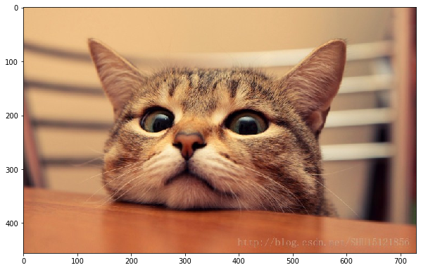

```python
plt.figure(figsize=(10,8))
plt.imshow(cat)
```

```python
# 行反转
cat1 = cat[::-1]
```

[figure not shown]

```python
plt.figure(figsize=(10,8))
plt.imshow(cat1)
```

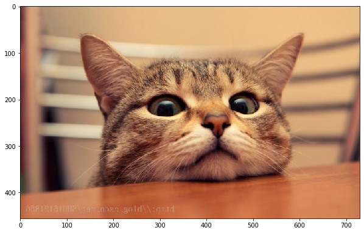

```python
# 列反转
cat2 = cat[:, ::-1]
plt.figure(figsize=(10,8))
plt.imshow(cat2)
```

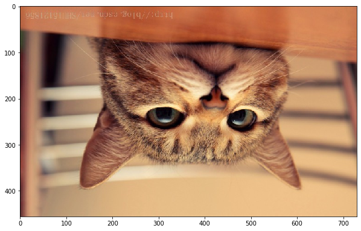

```python
cat3 = cat[::-1,  ::-1]
plt.figure(figsize=(10,8))
plt.imshow(cat3)
```

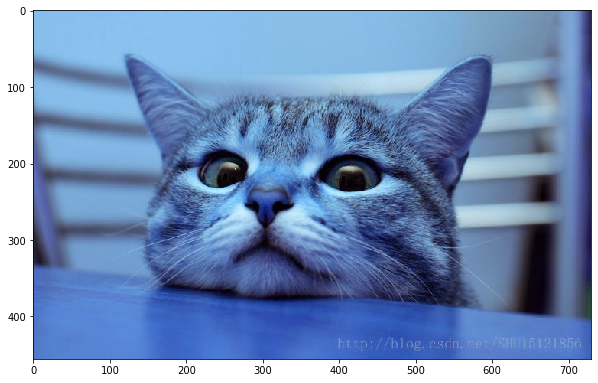

```python
cat4 = cat[:,:,::-1]
plt.figure(figsize=(10,8))
plt.imshow(cat4)
```

### 3. 变形

使用reshape函数，注意参数是一个tuple！

```python
n
```

```
array([[56, 53, 78, 55, 78, 24],
       [23, 24, 73, 18,  8, 40],
       [29, 90, 83, 59, 31, 36],
       [97, 59, 82,  2, 94, 57]])
```

```python
n.shape
```

```
(4, 6)
```

```python
# reshape改变shape
n.reshape((6,4))
```

```
array([[56, 53, 78, 55],
       [78, 24, 23, 24],
       [73, 18,  8, 40],
       [29, 90, 83, 59],
       [31, 36, 97, 59],
       [82,  2, 94, 57]])
```

```python
n.reshape(3,8)
```

```
array([[56, 53, 78, 55, 78, 24, 23, 24],
       [73, 18,  8, 40, 29, 90, 83, 59],
       [31, 36, 97, 59, 82,  2, 94, 57]])
```

```python
np.reshape(n, (3,8))
```

```
array([[56, 53, 78, 55, 78, 24, 23, 24],
       [73, 18,  8, 40, 29, 90, 83, 59],
       [31, 36, 97, 59, 82,  2, 94, 57]])
```

```python
n.shape
```

```
(4, 6)
```

```python
# 注意: reshape的时候,元素个数不能变
```

### 4. 级联

1. np.concatenate() 级联需要注意的点：
- 级联的参数是列表：一定要加中括号或小括号
- 维度必须相同
- 形状相符
- 【重点】级联的方向默认是shape这个tuple的第一个值所代表的维度方向
- 可通过axis参数改变级联的方向

```python
# axis 单数的轴  复数axes
# axis=0 对行进行操作即垂直级联, axis=1 对列操作, 水平级联
n1 = np.random.randint(0,100, size=(4,5))
n2 = np.random.randint(0,100, size=(4,5))
display(n1,n2)
np.concatenate((n1,n2), axis=0)
```

```
array([[99, 50, 67, 17, 40],
       [11, 35, 46, 52, 15],
       [23, 81,  9, 86, 99],
       [40, 63, 83, 34,  0]])
```

```
array([[92, 39, 96, 50, 84],
       [32,  0, 89, 12, 32],
       [31, 59, 75, 26, 25],
       [70, 47, 38, 35, 83]])
```

```
array([[99, 50, 67, 17, 40],
       [11, 35, 46, 52, 15],
       [23, 81,  9, 86, 99],
       [40, 63, 83, 34,  0],
       [92, 39, 96, 50, 84],
       [32,  0, 89, 12, 32],
       [31, 59, 75, 26, 25],
       [70, 47, 38, 35, 83]])
```

```python
# 水平级联
n1 = np.random.randint(0,100, size=(4,5))
n2 = np.random.randint(0,100, size=(4,5))
display(n1,n2)
np.concatenate((n1,n2), axis=1)
```

```
array([[71, 91, 70, 58, 37],
       [93, 41, 67, 68, 21],
       [81, 27, 94, 58, 68],
       [20, 18, 47, 30, 23]])
```

```
array([[11, 55, 56, 38, 24],
       [ 8, 21, 29, 44, 67],
       [49, 11, 22, 15, 93],
       [48, 42, 97,  1, 66]])
```

```
array([[71, 91, 70, 58, 37, 11, 55, 56, 38, 24],
       [93, 41, 67, 68, 21,  8, 21, 29, 44, 67],
       [81, 27, 94, 58, 68, 49, 11, 22, 15, 93],
       [20, 18, 47, 30, 23, 48, 42, 97,  1, 66]])
```

1. np.hstack与np.vstack  
   水平级联与垂直级联,处理自己，进行维度的变更

```python
# h=horizontal 水平
np.hstack((n1, n2))
```

```
array([[71, 91, 70, 58, 37, 11, 55, 56, 38, 24],
       [93, 41, 67, 68, 21,  8, 21, 29, 44, 67],
       [81, 27, 94, 58, 68, 49, 11, 22, 15, 93],
       [20, 18, 47, 30, 23, 48, 42, 97,  1, 66]])
```

```python
# v=vertical
np.vstack((n1,n2))
```

```
array([[71, 91, 70, 58, 37],
       [93, 41, 67, 68, 21],
       [81, 27, 94, 58, 68],
       [20, 18, 47, 30, 23],
       [11, 55, 56, 38, 24],
       [ 8, 21, 29, 44, 67],
       [49, 11, 22, 15, 93],
       [48, 42, 97,  1, 66]])
```

```python
n1 = np.random.randint(0,100, size=(4,3))
n2 = np.random.randint(0,100, size=(4,6))
display(n1,n2)
```

```
array([[30, 32, 93],
       [77, 87, 24],
       [32, 99, 30],
       [83, 69, 91]])
```

```
array([[28, 97, 55, 62, 51, 39],
       [61, 47, 63, 79, 83, 33],
       [10, 59, 71, 76, 94,  3],
       [42, 20, 40, 34,  5, 19]])
```

```python
np.vstack((n1,n2))
```

[output not shown]

```python
级联的基本要求: 垂直级联的时候 ,列数一定要相同, 水平级联行数一定要相同.
```

### 5. 切分

与级联类似，三个函数完成切分工作：

- np.split
- np.vsplit
- np.hsplit

```python
n = np.random.randint(0,100, size=(6,6))
n
```

```
array([[47, 19, 76, 79, 69, 89],
       [10, 40, 79, 53, 62, 29],
       [10, 39, 35, 47, 17, 63],
       [16, 72, 30, 25, 70, 42],
       [82, 66, 20, 94, 17, 46],
       [ 7, 39,  3, 70, 64,  7]])
```

```python
# 左闭右开 axis=0 ,对行进行切割
np.split(n, [2, 4], axis=0)
```

```
[array([[47, 19, 76, 79, 69, 89],
        [10, 40, 79, 53, 62, 29]]), array([[10, 39, 35, 47, 17, 63],
        [16, 72, 30, 25, 70, 42]]), array([[82, 66, 20, 94, 17, 46],
        [ 7, 39,  3, 70, 64,  7]])]
```

```python
np.split(n, [2, 4], axis=1)
```

```
[array([[47, 19],
        [10, 40],
        [10, 39],
        [16, 72],
        [82, 66],
        [ 7, 39]]), array([[76, 79],
        [79, 53],
        [35, 47],
        [30, 25],
        [20, 94],
        [ 3, 70]]), array([[69, 89],
        [62, 29],
        [17, 63],
        [70, 42],
        [17, 46],
        [64,  7]])]
```

```python
# axis=1
np.hsplit(n, [2,4])
```

```
[array([[47, 19],
        [10, 40],
        [10, 39],
        [16, 72],
        [82, 66],
        [ 7, 39]]), array([[76, 79],
        [79, 53],
        [35, 47],
        [30, 25],
        [20, 94],
        [ 3, 70]]), array([[69, 89],
        [62, 29],
        [17, 63],
        [70, 42],
        [17, 46],
        [64,  7]])]
```

```python
# axis=0 对 行进行切割
np.vsplit(n, [2,4])
```

```
[array([[47, 19, 76, 79, 69, 89],
        [10, 40, 79, 53, 62, 29]]), array([[10, 39, 35, 47, 17, 63],
        [16, 72, 30, 25, 70, 42]]), array([[82, 66, 20, 94, 17, 46],
        [ 7, 39,  3, 70, 64,  7]])]
```

### 6. 副本

所有赋值运算不会为ndarray的任何元素创建副本。对赋值后的对象的操作也对原来的对象生效。

```python
n
```

```
array([[47, 19, 76, 79, 69, 89],
       [10, 40, 79, 53, 62, 29],
       [10, 39, 35, 47, 17, 63],
       [16, 72, 30, 25, 70, 42],
       [82, 66, 20, 94, 17, 46],
       [ 7, 39,  3, 70, 64,  7]])
```

```python
n2 = n
```

```python
display(n, n2)
```

```
array([[47, 19, 76, 79, 69, 89],
       [10, 40, 79, 53, 62, 29],
       [10, 39, 35, 47, 17, 63],
       [16, 72, 30, 25, 70, 42],
       [82, 66, 20, 94, 17, 46],
       [ 7, 39,  3, 70, 64,  7]])
```

```
array([[47, 19, 76, 79, 69, 89],
       [10, 40, 79, 53, 62, 29],
       [10, 39, 35, 47, 17, 63],
       [16, 72, 30, 25, 70, 42],
       [82, 66, 20, 94, 17, 46],
       [ 7, 39,  3, 70, 64,  7]])
```

```python
n2[0,0] = 88
```

```python
n2
```

```
array([[88, 19, 76, 79, 69, 89],
       [10, 40, 79, 53, 62, 29],
       [10, 39, 35, 47, 17, 63],
       [16, 72, 30, 25, 70, 42],
       [82, 66, 20, 94, 17, 46],
       [ 7, 39,  3, 70, 64,  7]])
```

```python
n
```

```
array([[88, 19, 76, 79, 69, 89],
       [10, 40, 79, 53, 62, 29],
       [10, 39, 35, 47, 17, 63],
       [16, 72, 30, 25, 70, 42],
       [82, 66, 20, 94, 17, 46],
       [ 7, 39,  3, 70, 64,  7]])
```

```python
id(n)
```

```
327719632
```

```python
id(n2)
```

```
327719632
```

可使用copy()函数创建副本

```python
n3 = n.copy()
```

```python
id(n3)
```

```
343129664
```

```python
id(n)
```

```
327719632
```

```python
n3[0,0]  = 108
n3
```

```
array([[108,  19,  76,  79,  69,  89],
       [ 10,  40,  79,  53,  62,  29],
       [ 10,  39,  35,  47,  17,  63],
       [ 16,  72,  30,  25,  70,  42],
       [ 82,  66,  20,  94,  17,  46],
       [  7,  39,   3,  70,  64,   7]])
```

```python
n
```

```
array([[88, 19, 76, 79, 69, 89],
       [10, 40, 79, 53, 62, 29],
       [10, 39, 35, 47, 17, 63],
       [16, 72, 30, 25, 70, 42],
       [82, 66, 20, 94, 17, 46],
       [ 7, 39,  3, 70, 64,  7]])
```

```python
n.view()
```

```python
l = [i for  i in range(100000)]
l.__sizeof__()
```

```
824440
```

```python
np.array(l).__sizeof__()
```

```
400096
```

## 四、ndarray的聚合操作

### 1. 求和np.sum

```python
n
```

```
array([[88, 19, 76, 79, 69, 89],
       [10, 40, 79, 53, 62, 29],
       [10, 39, 35, 47, 17, 63],
       [16, 72, 30, 25, 70, 42],
       [82, 66, 20, 94, 17, 46],
       [ 7, 39,  3, 70, 64,  7]])
```

```python
n.sum() # axis=None 表示所有的维度都聚合成0维
```

```
1674
```

```python
# axis=0 表示对行进行聚合操作,行没了,剩下列.
n.sum(axis=0)
```

```
array([213, 275, 243, 368, 299, 276])
```

```python
# axis=1表示对列进行聚合,列没了,行还在.
n.sum(axis=1)
```

```
array([420, 273, 211, 255, 325, 190])
```

```python
np.sum(n, axis=0)
```

```
array([213, 275, 243, 368, 299, 276])
```

### 2. 最大最小值：np.max/ np.min

同理

```python
n.max(axis=0)
```

```
array([88, 72, 79, 94, 70, 89])
```

```python
n.min(axis=1)
```

```
array([19, 10, 10, 16, 17,  3])
```

### 3. 其他聚合操作

```
Function Name   NaN-safe Version    Description
np.sum  np.nansum   Compute sum of elements
np.prod np.nanprod  Compute product of elements
np.mean np.nanmean  Compute mean of elements
np.std  np.nanstd   Compute standard deviation
np.var  np.nanvar   Compute variance
np.min  np.nanmin   Find minimum value
np.max  np.nanmax   Find maximum value
np.argmin   np.nanargmin    Find index of minimum value
np.argmax   np.nanargmax    Find index of maximum value
np.median   np.nanmedian    Compute median of elements
np.percentile   np.nanpercentile    Compute rank-based statistics of elements
np.any  N/A Evaluate whether any elements are true
np.all  N/A Evaluate whether all elements are true
np.power 幂运算
```

```python
# 笛卡尔积 product
```

```python
n
```

```
array([[88, 19, 76, 79, 69, 89],
       [10, 40, 79, 53, 62, 29],
       [10, 39, 35, 47, 17, 63],
       [16, 72, 30, 25, 70, 42],
       [82, 66, 20, 94, 17, 46],
       [ 7, 39,  3, 70, 64,  7]])
```

```python
# 返回最小值的索引
n.argmin(axis=0)
```

```
array([5, 0, 5, 3, 2, 5], dtype=int64)
```

```python
any([' ', [],  (),  {}])
```

```
True
```

```python
all([' ', [],  (),  {}])
```

```
False
```

```python
# 只要有True就返回True
np.any([1,2,3,4])
```

```
True
```

```python
# 只要有False就会返回False
np.all([0,2,3,4])
```

```
False
```

```python
np.nan 一般用来表示numpy, pandas中的空数据.
```

np.sum 和 np.nansum 的区别 nan not a number

```python
n3 = np.array([1,2,3,4, np.nan])
n3.sum()
```

```
nan
```

```python
# n3.nansum() # 没有这样的函数
np.nansum(n3)
```

```
10.0
```

#### 操作文件

使用pandas打开文件president_heights.csv 获取文件中的数据

```python
import pandas as pd
```

```python
heights = pd.read_csv('./president_heights.csv')
```

```python
#  DataFrame
heights
```

|  | order | name | height(cm) |
| --- | --- | --- | --- |
| 0 | 1 | George Washington | 189 |
| 1 | 2 | John Adams | 170 |
| 2 | 3 | Thomas Jefferson | 189 |
| 3 | 4 | James Madison | 163 |
| 4 | 5 | James Monroe | 183 |
| 5 | 6 | John Quincy Adams | 171 |
| 6 | 7 | Andrew Jackson | 185 |
| 7 | 8 | Martin Van Buren | 168 |
| 8 | 9 | William Henry Harrison | 173 |
| 9 | 10 | John Tyler | 183 |
| 10 | 11 | James K. Polk | 173 |
| 11 | 12 | Zachary Taylor | 173 |
| 12 | 13 | Millard Fillmore | 175 |
| 13 | 14 | Franklin Pierce | 178 |
| 14 | 15 | James Buchanan | 183 |
| 15 | 16 | Abraham Lincoln | 193 |
| 16 | 17 | Andrew Johnson | 178 |
| 17 | 18 | Ulysses S. Grant | 173 |
| 18 | 19 | Rutherford B. Hayes | 174 |
| 19 | 20 | James A. Garfield | 183 |
| 20 | 21 | Chester A. Arthur | 183 |
| 21 | 23 | Benjamin Harrison | 168 |
| 22 | 25 | William McKinley | 170 |
| 23 | 26 | Theodore Roosevelt | 178 |
| 24 | 27 | William Howard Taft | 182 |
| 25 | 28 | Woodrow Wilson | 180 |
| 26 | 29 | Warren G. Harding | 183 |
| 27 | 30 | Calvin Coolidge | 178 |
| 28 | 31 | Herbert Hoover | 182 |
| 29 | 32 | Franklin D. Roosevelt | 188 |
| 30 | 33 | Harry S. Truman | 175 |
| 31 | 34 | Dwight D. Eisenhower | 179 |
| 32 | 35 | John F. Kennedy | 183 |
| 33 | 36 | Lyndon B. Johnson | 193 |
| 34 | 37 | Richard Nixon | 182 |
| 35 | 38 | Gerald Ford | 183 |
| 36 | 39 | Jimmy Carter | 177 |
| 37 | 40 | Ronald Reagan | 185 |
| 38 | 41 | George H. W. Bush | 188 |
| 39 | 42 | Bill Clinton | 188 |
| 40 | 43 | George W. Bush | 182 |
| 41 | 44 | Barack Obama | 185 |

```python
data = heights['height(cm)'].values
```

```python
# 美国历任总统平均身高
data.mean()
```

```
179.73809523809524
```

```python
# 最高身高
data.max()
```

```
193
```

```python
data.min()
```

```
163
```

```python
data.std()
```

```
6.931843442745892
```

## 五、ndarray的矩阵操作

### 1. 基本矩阵操作

1) 算术运算符：

- 加减乘除

```python
n
```

```
array([[88, 19, 76, 79, 69, 89],
       [10, 40, 79, 53, 62, 29],
       [10, 39, 35, 47, 17, 63],
       [16, 72, 30, 25, 70, 42],
       [82, 66, 20, 94, 17, 46],
       [ 7, 39,  3, 70, 64,  7]])
```

```python
n + 1 # 每个元素分别加1
```

```
array([[89, 20, 77, 80, 70, 90],
       [11, 41, 80, 54, 63, 30],
       [11, 40, 36, 48, 18, 64],
       [17, 73, 31, 26, 71, 43],
       [83, 67, 21, 95, 18, 47],
       [ 8, 40,  4, 71, 65,  8]])
```

```python
n + n2 # 对应的元素进行运算.
```

```
array([[176,  38, 152, 158, 138, 178],
       [ 20,  80, 158, 106, 124,  58],
       [ 20,  78,  70,  94,  34, 126],
       [ 32, 144,  60,  50, 140,  84],
       [164, 132,  40, 188,  34,  92],
       [ 14,  78,   6, 140, 128,  14]])
```

```python
n1 = np.random.randint(0,10, size=(4,5))
n2 = np.random.randint(0,10, size=(5,4))

n1 + n2
```

```
---------------------------------------------------------------------------
ValueError                                Traceback (most recent call last)
<ipython-input-126-58253959e688> in <module>
      2 n2 = np.random.randint(0,10, size=(5,4))
      3
----> 4 n1 + n2

ValueError: operands could not be broadcast together with shapes (4,5) (5,4)
```

```python
display(n1, n2)
```

```
array([[5, 0, 6, 8, 2],
       [9, 6, 2, 5, 2],
       [6, 7, 1, 9, 6],
       [7, 0, 2, 2, 6]])
```

```
array([[1, 5, 9, 8],
       [3, 6, 5, 9],
       [6, 5, 9, 8],
       [7, 1, 8, 6],
       [6, 2, 1, 5]])
```

2) 矩阵积np.dot()

```python
a * b # 普通乘法,对应元素相乘
```

[output not shown]

```python
矩阵的积,矩阵的点乘.要求第一个矩阵的列数和第二个矩阵的行数要相同才行.
矩阵的积是有顺序的,不满足乘法的交换律.
```

```python
a * b = b * a
如果是矩阵,交换律不成立.
```

```python
n1  = np.random.randint(0,10, size=(4,5))
n2 = np.random.randint(0,10, size=(5, 6))
np.dot(n1, n2)
```

```
array([[ 58,  48,  29,  90,  10,  63],
       [ 54,  84,  62,  68,  19,  76],
       [104, 113,  74, 124,  72,  72],
       [112, 151,  81,  84,  44, 163]])
```

### 2. 广播机制

【重要】ndarray广播机制的两条规则

- 规则一：为缺失的维度补1
- 规则二：假定缺失元素用已有值填充

例1： m = np.ones((2, 3)) a = np.arange(3) 求m+a

```python
# 当运算的ndarray的shape不一致的时候,numpy就会启动广播机制.目的就是为了让运算的两个ndarray的shape变成一样.
```

```python
m = np.ones((2, 3))
a = np.arange(3)
display(m, a)
```

```
array([[1., 1., 1.],
       [1., 1., 1.]])
```

```
array([0, 1, 2])
```

```python
m + a
```

```
array([[1., 2., 3.],
       [1., 2., 3.]])
```

```python
[[1., 1., 1.],         +              [[0,1,2],
[1., 1., 1.]]                        [0,1,2]]
```

例2： a = np.arange(3).reshape((3, 1)) b = np.arange(3) 求a+b

```python
a = np.arange(3).reshape((3, 1))
a
```

```
array([[0],
       [1],
       [2]])
```

```python
b = np.arange(3)
b
```

```
array([0, 1, 2])
```

```python
a + b
```

```
array([[0, 1, 2],
       [1, 2, 3],
       [2, 3, 4]])
```

```python
[[0,0,0],
[1,1,1,],
[2,2,2]]
```

```python
[[0, 1, 2],
[0, 1, 2],
[0, 1, 2]]
```

习题 a = np.ones((4, 1)) b = np.arange(4) 求a+b

```python
a = np.ones((4, 1))
a
```

```
array([[1.],
       [1.],
       [1.],
       [1.]])
```

```python
b = np.arange(4)
```

```python
b
```

```
array([0, 1, 2, 3])
```

```python
a + b
```

```
array([[1., 2., 3., 4.],
       [1., 2., 3., 4.],
       [1., 2., 3., 4.],
       [1., 2., 3., 4.]])
```

## 六、ndarray的排序

小测验： 使用以上所学numpy的知识，对一个ndarray对象进行选择排序。

def Sortn(x):

代码越短越好

```python
排序只对一维数组有意义.
```

```python
def select_sort(arr):
    # 假定第一个元素已经排序好了,
    for i in range(0, len(arr)):
        # 从待排序的数组中选出最小的元素的索引
        index = np.argmin(arr[i:]) + i
        if arr[i] > arr[index]:
            # 交换位置
            arr[i], arr[index] = arr[index], arr[i]
    return arr
```

```python
n = np.array([6,2,1,4,3])
select_sort(n)
```

```
array([1, 2, 3, 4, 6])
```

### 1. 快速排序

np.sort()与ndarray.sort()都可以，但有区别：

- np.sort()不改变输入
- ndarray.sort()本地处理，不占用空间，但改变输入

```python
n = np.array([6,2,1,4,3])
```

```python
np.sort(n)
```

```
array([1, 2, 3, 4, 6])
```

```python
n.sort()# 会修改原始数据
```

```python
n
```

```
array([1, 2, 3, 4, 6])
```

### 2. 部分排序

```python
n = np.random.randint(0,100, size=100)
n
```

```
array([45, 11, 24,  0, 27, 37, 72, 99, 93, 57, 36, 81, 55, 25, 65, 26, 26,
       86, 10, 24, 15, 65, 71, 17, 36, 15, 27, 35, 54, 51,  9, 38, 59, 27,
       31, 87, 50, 26, 70, 69, 93, 59, 98, 24,  8, 51, 67, 39, 80, 55, 82,
       42, 19, 32, 78, 84, 66, 36, 88, 19, 34, 83, 47, 88, 90, 63, 13, 23,
       90, 38, 83,  4, 39, 89, 19, 41, 30, 72, 16, 29, 15, 81, 94,  0, 92,
       68, 45, 51, 91, 27, 49, 56, 77,  4, 81, 16, 47, 80,  1,  0])
```

```python
# 最大的5个
np.partition(n, kth=-5)
```

```
array([11,  0, 24,  0, 27, 37,  1, 16,  4, 27, 36, 45,  0, 25, 15, 26, 26,
       29, 10, 24, 15, 16, 30, 17, 36, 15, 27, 35, 41, 19,  9, 38, 39, 27,
       31,  4, 38, 26, 23, 13, 34, 19, 36, 24,  8, 32, 19, 39, 42, 45, 47,
       51, 47, 51, 49, 51, 55, 54, 50, 55, 81, 82, 59, 72, 80, 63, 69, 70,
       67, 81, 83, 77, 59, 56, 80, 78, 71, 72, 65, 83, 65, 81, 57, 66, 84,
       68, 86, 90, 92, 88, 90, 89, 87, 91, 88, 93, 99, 98, 94, 93])
```

```python
# 最小的5个.
np.partition(n, kth=5)
```

```
array([ 0,  0,  0,  1,  4,  4,  8,  9, 10, 11, 19, 13, 16, 15, 15, 19, 17,
       16, 19, 15, 23, 29, 30, 26, 26, 25, 27, 35, 24, 32, 27, 36, 27, 27,
       31, 24, 34, 26, 24, 36, 38, 39, 38, 41, 45, 36, 37, 39, 42, 45, 82,
       80, 67, 51, 78, 84, 66, 98, 88, 59, 93, 83, 47, 88, 90, 63, 69, 70,
       90, 50, 83, 87, 59, 89, 51, 54, 71, 72, 65, 86, 65, 81, 94, 55, 92,
       68, 81, 51, 91, 57, 49, 56, 77, 93, 81, 99, 47, 80, 72, 55])
```